# Bruhn_A11_3

### 例題 13

支持点における梁の曲げモーメントは、モーメント分配法によって決定されます。

諸係数の計算：

**スパン AB**

$$I = 17.21, \quad L = 100, \quad I/L = .172$$

$$E = 1300000, \quad P = 8565$$

$$j = \sqrt{\frac{EI}{P}} = \sqrt{\frac{1300000 \times 17.21}{8565}} = 51.1$$

$$/j = 100 / 51.1 = 1.96$$

Fig. A11.47 から、 $L/j = 1.96$ のとき、固定遠端に対して補正係数 $= .86$ 、ピン支持遠端に対しては $.52$ となります。したがって、

$$K_{AB} = .52 \times .172 = .0895$$

$$K_{BA} = .86 \times .172 = .148$$

Fig. A11.46 から、 $L/j = 1.96$ のとき、到達率は以下の通りです：

$C_{O.BA} = .62$ 、またBは真の支持状態または自由に支持されているとみなされるため、AからBへはゼロとなります。Fig. A11.48 から、 $L/j = 1.96$ のとき、等分布荷重に対する固定端モーメントの式は $wL^2/11.25 = 32 \times 100^2 / 11.25 = 28420 \text{ in. lb.}$ となります。

張出しモーメント $M_{BC} = 60 \times 26.6 \times (32 + 16)/2 = 38300 \text{ in. lb.}$

**中央スパン AA’**

$$I = 22, \quad I/L = 22/84 = .262, \quad P = -11758$$

$$j = \sqrt{\frac{1300000 \times 22}{11758}} = 49.4$$

$$L/j = 84 / 49.4 = 1.70$$

$$K_{AA'} = K_{A'A} = .262 \times .895 = .234$$

到達率 $= .585$

All 27

固定端モーメント $= wL^2 / 11.35 = 31 \times 84^2 / 11.35 = 19300 \text{ in. lb.}$

モーメント分配プロセスは Fig. A11.60 に示されています。軸荷重を無視した場合、支持点AおよびA’における曲げモーメントは19480となります。したがって、軸方向の影響により、Aにおけるモーメントは約7.5%増加します。

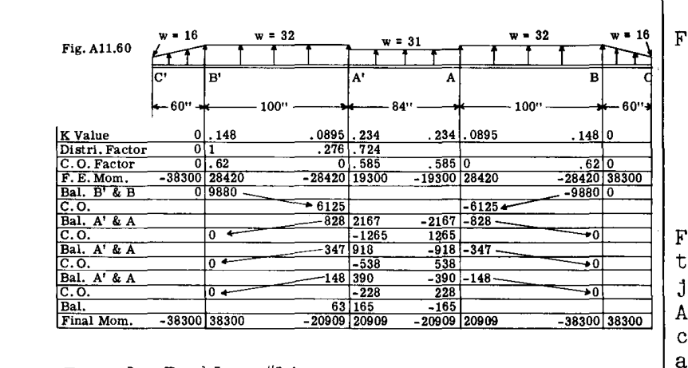

Fig. A11.60

### 例題 14

Fig. A11.61 は、AおよびBで固定され、Cで車軸バーに剛に結合された2つの部材からなる三角形トラスを示しています。節点の回転および移動に対する軸荷重の影響を考慮して、2つの部材の端部モーメントを決定することが求められています。

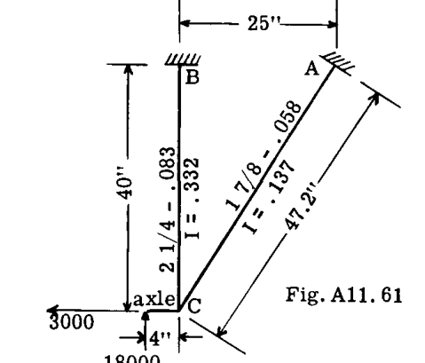

Fig. A11.61

### 解答

また、せん断反力は、

$$S_A = 198 \text{ lb.} \quad \text{および} \quad S_B = 2332 \text{ lb.}$$

軸荷重が既知であれば、修正された梁の諸係数を決定できます。

**部材 BC**

$$P = -27150, \quad I/L = .0083, \quad I = .332$$

$$j = \left( \frac{29,000,000 \times .332}{27150} \right)^{1/2} = 18.82, \quad L/j = \frac{40}{18.82} = 2.12$$

Fig. A11.47 から、剛性係数 $= .82 \times .0083 = .00681$

Fig. A11.46 から、到達率 $= .66$

**部材 AC**

$$P = 10400, \quad I/L = .0029, \quad I = .137$$

$$j = \sqrt{\frac{29,000,000 \times .137}{10400}} = 19.58, \quad L/j = \frac{47.20}{19.58} = 2.42$$

剛性係数 $= .0029 \times 1.18 = .00342$  
到達率 $= .39$

Fig. A11.63 は、節点回転に対する軸荷重の影響を含むモーメント分配の解を示しています。Fig. A11.62 と Fig. A11.63 の結果を比較すると、 $24050 \text{ in. lb.}$ のモーメント $M_{CA}$ は、Fig. A11.62 のものより 29% 大きく、Bにおけるモーメントは 18% 大きくなっています。これらの新しい最終モーメントによる軸荷重への影響は非常に小さいため、さらなる修正は不要です。

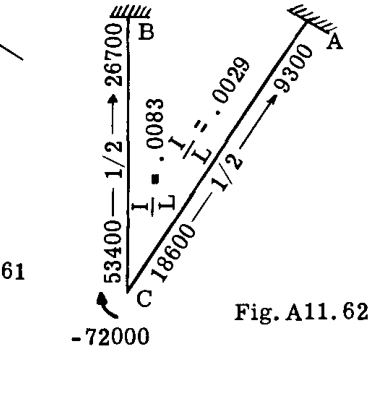

Fig. A11.62

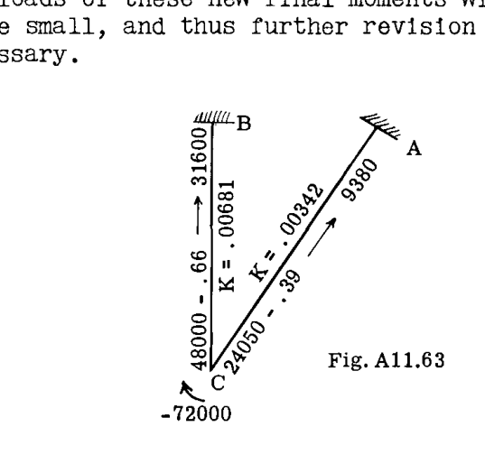

Fig. A11.63

### 軸荷重による節点Cの移動に起因する端部モーメントへの影響

各部材に対して垂直な節点Cの移動は、仮想仕事法によって計算されます（Chapter A7 参照）。Fig. A11.64 は、Cにおいて各部材に垂直な $1 \text{ lb.}$ の仮想荷重を示しています。表は、Cにおける法線方向たわみの計算を示しています。

**Table**

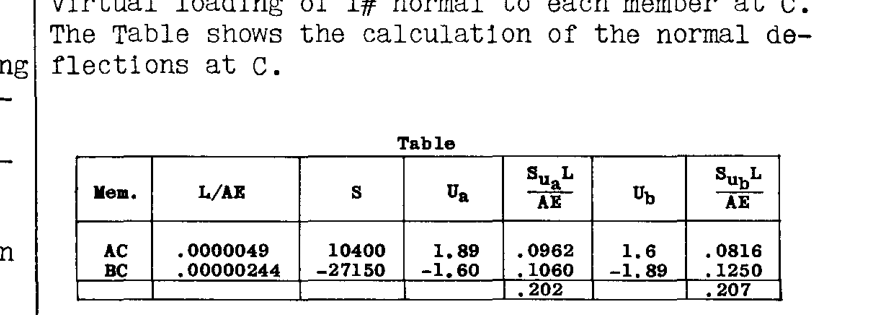

Table

したがって、BCに対して垂直な節点Cのたわみは、単位荷重に対して仮定された方向に $.202 \text{ in.}$ となり、ACに垂直なたわみは $= .207 \text{ in.}$ となります。

All.28 モーメント分配法

支持点たわみによる固定端モーメントは、Art. A11.7 で導出されたように $M = 6EId/L^2$ に等しくなります。しかし、軸荷重による二次モーメントに横方向たわみを乗じたものは、この式を修正します。“James” は、修正された式が次式のようになることを示しました。

$$M_{\text{fixed end}} = \frac{6EId}{L^2(2\beta-\alpha)}$$

ここで、 $K = I/L$ および $R = d/L$ とすると、

$$M = \frac{6EKR}{2\beta-\alpha}$$

Fig. A11.56 は、 $L/j$ に対する $2\beta-\alpha$ のプロットを示しています。

**部材 BC**

$$R = .202/40 = .00505, \quad K = I/L = .0083$$

$$2\beta-\alpha = 1.08 \quad (L/j = 2.12 \text{ に対して})$$

したがって、節点Cの移動による固定端モーメントは以下の通りです。

$$M_{BC} = M_{CB} = \frac{6 \times .0083 \times .00505 \times 29,000,000}{1.08} = -6750 \text{ in. lb.}$$

**部材 AC**

$$R = .207/47.2 = .00438, \quad K = .0029, \quad 2\beta-\alpha = .92$$

ここで $L/j = 2.42$ であり、部材は引張状態にあります。したがって、

$$M_{AC} = M_{CA} = \frac{6 \times .00438 \times .0029 \times 29,000,000}{.92} = -2400 \text{ in. lb.}$$

モーメントが部材端部を反時計回りに回転させる傾向があることが観察からわかるため、符号はマイナスになります（Art. A11.2 参照）。

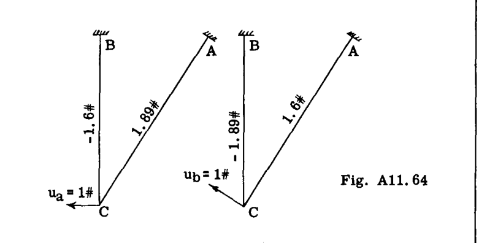

Fig. A11.64

[figure not shown]

Fig. A11.65

## A11.15 剛節点を持つトラスの二次曲げモーメント *

航空機の構造設計では、剛節点を持つトラスがしばしば使用されます。剛節点は、トラス節点において部材を溶接すること、あるいは各部材にボルトやリベットで留められたガセットプレートを使用することによって生じます。トラスが荷重下で曲がると、トラス節点は異なる量の移動またはたわみを受けます。トラス部材は節点で剛に保持されているため、節点の移動は部材を曲げる傾向があります。トラス節点のたわみによってトラス部材に生じる曲げモーメントは、一般に二次モーメントと呼ばれ、これらのモーメントによって生じる応力は二次応力と呼ばれます。

航空機の構造設計において疲労強度の重要性が高まっているため、二次応力の問題は過去よりも重要になってきています。モーメント分配法は、トラスのたわみによるトラス部材の二次モーメントを決定するための、シンプルで迅速な方法を提供します。一般的な手順は以下の通りです。

1. 決定的な設計条件による各トラス節点の水平および垂直変位を求めます（トラスのたわみを求める方法については Chapter A7 を参照）。
2. これらの変位から、各トラス部材について、一端の他端に対する横方向たわみを求めることができます。
3. これらの横方向変位による各部材の固定端モーメントを計算します。
4. 各トラス部材の剛性および到達率を計算します。
5. 各トラス節点の分配率を計算します。
6. モーメント分配プロセスを実行して、各部材の端部における二次モーメントを求めます。
7. これらの二次モーメントによる応力を計算し、ピン支持トラス節点を持つトラス作用による部材の一次軸応力と組み合わせます。

## A11.16 曲線部材を持つ構造物

モーメント分配法は、直線部材だけでなく曲線部材を含む連続構造物にも適用できます。直線部材の剛性係数、到達率、および固定端モーメントを求めるための公式は、曲線部材には使用できません。弾性中心法（Chapter C2, Part H を参照）を使用する必要があります。

- Chapter C2, Part H も参照してください。